# Homework 5

Charles Hanks

02/08/2023

**Directions:**

Please turn in **both** a knitted HTML file *and* your Rmd file on WISE.

Good luck!

# 1. Setup (1pt)

Change the author of this RMD file to be yourself and modify the below code so that you can successfully load the ‘pinot.rds’ data file from your own computer.

```r
knitr::opts_chunk$set(echo = TRUE, message = FALSE, warning = FALSE)
library(tidyverse)
library(caret)
library(naivebayes)
wine = read_rds("pinot.rds")
```

# 2. Logistic Concepts (3pts)

Why do we call it Logistic Regression even though we are using the technique for classification?

**Answer:** We call it logistic regression because the model is calculating a binomial probability, which will be a continuous variable. If one runs `predict(fit, newdata=test)`, the result is the probability for each row. This probability is the likelihood that the response variable is or is not what we are classifying. It is for us to decide what the cutoff point is to make that decision. For example, if we are predicting if a wine in from Oregon, if this probability is above .5, it is enough to predict the wine’s province as from Oregon.

# 3. Modeling (4pts)

1. Train a logistic regression algorithm to classify a whether a wine comes from Marlborough,
2. using 80% of your data,
3. three features engineered from the description
4. and 5-fold cross validation.
5. Report Kappa after using your model to predict the province in the holdout sample.

```r
wine <-  read_rds("pinot.rds") %>%
  mutate(province = as.numeric(province=="Marlborough"))

## create a function to extract words with totals > j

wine_words <- function(df, j = 1000, stem=F){
  library(tidytext)
  library(SnowballC)
  data(stop_words)

  words <- df %>%
    unnest_tokens(word, description) %>%
    anti_join(stop_words) %>% # get rid of stop words
    filter(!(word %in% c("wine","pinot","vineyard")))

  if(stem){
    words <- words %>%
      mutate(word = wordStem(word))
  }

  words <- words %>%
    count(id, word) %>%
    group_by(id) %>%
    mutate(exists = (n>0)) %>%
    ungroup %>%
    group_by(word) %>%
    mutate(total = sum(n)) %>%
    filter(total > j) %>%
    pivot_wider(id_cols = id, names_from = word, values_from = exists, values_fill = list(exists=0)) %>%
    right_join(dplyr::select(df,id,province)) %>%
    #drop_na() #%>%
    dplyr::select(-id)


  words <- replace(words, is.na(words), FALSE)
}

wino <- wine_words(wine)

set.seed(504)

wine_index <- createDataPartition(wino$province, p = 0.80, list = FALSE)

train <- wino[ wine_index, ]
test <- wino[-wine_index, ]

control <- trainControl(method = "cv", number = 5)

fit <- train(province ~ .,
             data = train,
             trControl = control,
             method = "glm",
             family = "binomial")

#show the odds ratios for top coefficients
odds_ratio <- exp(coef(fit$finalModel))
data.frame(name = names(odds_ratio), odds_ratio = odds_ratio) %>%
  arrange(desc(odds_ratio)) %>%
  head(10)
```

|  | name | odds_ratio |
| --- | --- | --- |
| drinkTRUE | drinkTRUE | 18.4086840 |
| bodiedTRUE | bodiedTRUE | 5.9273792 |
| finishTRUE | finishTRUE | 3.5200313 |
| aromasTRUE | aromasTRUE | 2.3544284 |
| cherryTRUE | cherryTRUE | 1.3883252 |
| fruitTRUE | fruitTRUE | 1.1985089 |
| palateTRUE | palateTRUE | 0.8682476 |
| noseTRUE | noseTRUE | 0.8256170 |
| tanninsTRUE | tanninsTRUE | 0.7904971 |
| darkTRUE | darkTRUE | 0.7186261 |

```r
#top 3 words are drink, bodied, and finish

wino_marl = wino %>% dplyr::select(province, drink, bodied, finish)

wine_index <- createDataPartition(wino_marl$province, p = 0.80, list = FALSE)

train <- wino_marl[ wine_index, ]
test <- wino_marl[-wine_index, ]

control <- trainControl(method = "cv", number = 5)

fit <- train(province ~ .,
             data = train,
             trControl = control,
             method = "glm",
             family = "binomial")

prob <- predict(fit, newdata=test)
pred <- ifelse(prob > 0.5, 1, 0)

confusionMatrix(factor(pred),factor(test$province))
```

```
## Confusion Matrix and Statistics
##
##           Reference
## Prediction    0    1
##          0 1622   50
##          1    1    3
##
##                Accuracy : 0.9696
##                  95% CI : (0.9602, 0.9773)
##     No Information Rate : 0.9684
##     P-Value [Acc > NIR] : 0.4253
##
##                   Kappa : 0.1013
##
##  Mcnemar's Test P-Value : 1.801e-11
##
##             Sensitivity : 0.9994
##             Specificity : 0.0566
##          Pos Pred Value : 0.9701
##          Neg Pred Value : 0.7500
##              Prevalence : 0.9684
##          Detection Rate : 0.9678
##    Detection Prevalence : 0.9976
##       Balanced Accuracy : 0.5280
##
##        'Positive' Class : 0
##
```

ANSWER: kappa = .101

# 4. Weighting (3pts)

Rerun the above model with a 15 to 1 weight on Marlborough

```r
weight_train <- train %>%
  mutate(weights=if_else(province==1,15,1))

fit <- train(province ~ .,
             data = train,
             trControl = trainControl(method = "cv", number = 5),
             method = "glm",
             family = "binomial",
             weights = weight_train$weights)

prob <- predict(fit, newdata=test)
pred <- ifelse(prob > 0.5, 1, 0)

confusionMatrix(factor(pred),factor(test$province))
```

```
## Confusion Matrix and Statistics
##
##           Reference
## Prediction    0    1
##          0 1554   24
##          1   69   29
##
##                Accuracy : 0.9445
##                  95% CI : (0.9325, 0.955)
##     No Information Rate : 0.9684
##     P-Value [Acc > NIR] : 1
##
##                   Kappa : 0.3577
##
##  Mcnemar's Test P-Value : 5.053e-06
##
##             Sensitivity : 0.9575
##             Specificity : 0.5472
##          Pos Pred Value : 0.9848
##          Neg Pred Value : 0.2959
##              Prevalence : 0.9684
##          Detection Rate : 0.9272
##    Detection Prevalence : 0.9415
##       Balanced Accuracy : 0.7523
##
##        'Positive' Class : 0
##
```

# 5. ROC Curves (5pts)

Display an ROC for the model you ran in the last question and use it to explain your model’s quality.

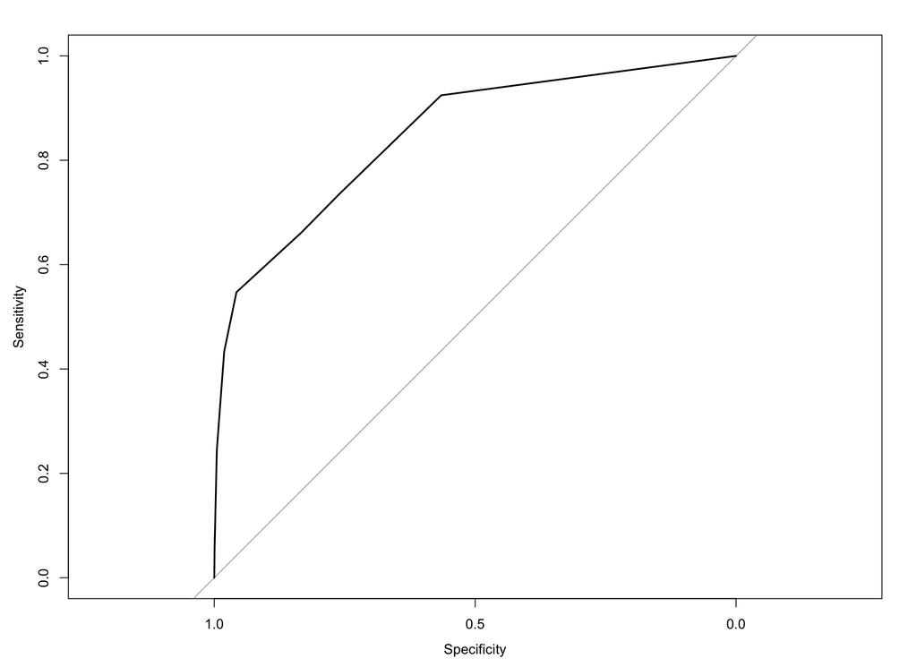

```r
library(pROC)
myRoc <- roc(test$province, prob)
plot(myRoc)
```

```r
auc(myRoc)
```

```
## Area under the curve: 0.8487
```

*Note:* You can find a tutorial on ROC curves here: https://towardsdatascience.com/understanding-auc-roc-curve-68b2303cc9c5